# NetPriori

### El triángulo

Preparamos la red que vamos a usar:

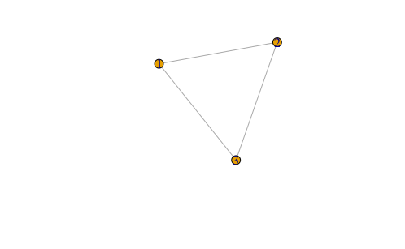

```r
g = make_empty_graph(n=3,directed=FALSE)
g = add_edges(g,c(1,2,1,3,2,3))
plot(g)
```

```r
X = as_adjacency_matrix(g,sparse = FALSE)
```

El triángulo incluye tres links, por lo que en principio tenemos nueve parámetros distintos en el vector $z=(z_{12},z_{13},z_{23})$. Por otro lado, tenemos tres uniones, es decir, tres condiciones de vínculo. Eso resulta en seis parámetros $\eta_i$ libres a elegir.

Armamos la matriz de constraints, y el proyector.

```r
Z = generate_state_vector(X)
A = generate_constraint_matrix(X)
P = generate_proyector(A)
print('El vector Z')
```

```
[1] "El vector Z"
```

```r
print(Z)
```

```
[1] "12"  "1n2" "n12" "13"  "1n3" "n13" "23"
[8] "2n3" "n23"
```

```r
print('La matriz de constraints')
```

```
[1] "La matriz de constraints"
```

```r
print(A)
```

```
     12 1n2 n12 13 1n3 n13 23 2n3 n23
[1,]  1   1   0 -1  -1   0  0   0   0
[2,]  1   0   1  0   0   0 -1  -1   0
[3,]  0   0   0  1   0   1 -1   0  -1
```

```r
print('El proyector')
```

```
[1] "El proyector"
```

```r
print(fractions(P))
```

```
      [,1]               [,2]
 [1,]          1825/9836          1974/5399
 [2,]         7316/16575        13571/40349
 [3,]      163901/663992    -682743/2928593
 [4,]      168620/236189        -4119/36406
 [5,]    -418588/4811951      125209/153611
 [6,]  -5488799/27569302         1225/17072
 [7,]      156767/496510    509781/16786145
 [8,]        10613/90984         2303/22551
 [9,] 27310046/137173707         -958/13351
      [,3]               [,4]
 [1,]       -10532/58485        18119/35607
 [2,]       60855/579311         -1106/2307
 [3,]      412891/860240       -13661/78646
 [4,]        -2711/15676         8248/66767
 [5,]       10751/109809          -132/1403
 [6,]    1431269/1962917       29215/134249
 [7,]        26188/91769        12303/22018
 [8,]  3188191/219529921         -1180/5277
 [9,]     558163/2060814        -9474/43535
      [,5]               [,6]
 [1,]   6134984/18659831        12011/66698
 [2,]       -14331/38281      -16001/152322
 [3,]         3444/11245     -336455/700989
 [4,]     -79091/1600856         8496/49127
 [5,]          243/63572        -7702/78667
 [6,]        -1945/36541     558163/2060814
 [7,]        -5224/33517       -16397/57459
 [8,]          3968/5017   -524843/36139222
 [9,]         4139/77760    1431269/1962917
```

En este caso, no podemos asociar a ninguno de los $v_i$ a un $\theta$ en particular. Esto tiene sentido ya que todos los nodos están vinculados entre sí.

Definimos los parámetros para las distribuciones de cada link

```r
gamma = 10
kappa_sum = 22
kappas = generate_kappas(Z,gamma = gamma,K=kappa_sum)
print(kappas)
```

```
 [1] 10  1  1 10 10  1  1 10 10  1  1 10
```

```r
params = list('kappas'=kappas,'K'=P)
```

Y ahora lo bueno, definimos los parámetros para la simulación:

```r
z0 = generate_z0(kappas,kappa_sum)
initial = t(P)%*%z0
density = density_eta
samples0 = sampling(density = density,initial=initial,params=params,full.result = FALSE,scale=6e-2)
```

Y con esto cargado, podemos explorar un poco los resultados:

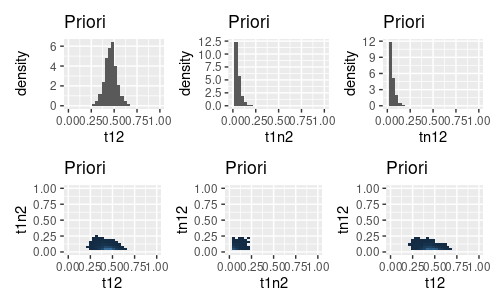

```r
df0 = as.data.frame(t(P%*%t(samples0)))
colnames(df0) = paste('t',Z,sep='')
ggL0 = make_ggmagic(df0)
print(ggL0$gL1)
```

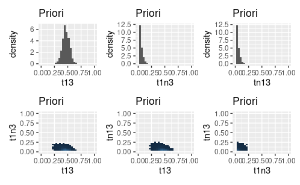

```r
print(ggL0$gL2)
```

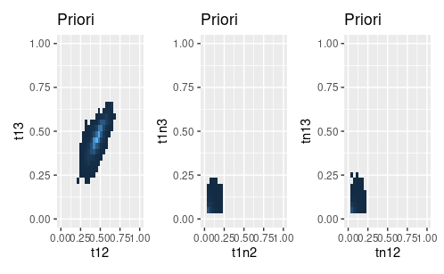

```r
print(ggL0$gL3)
```

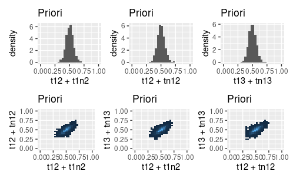

```r
print(ggL0$gL4)
```

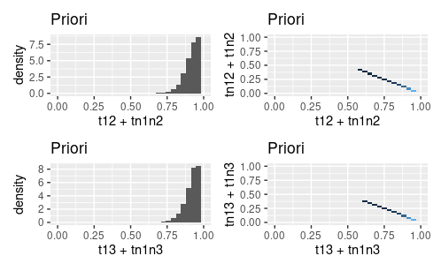

```r
print(ggL0$gL5)
```

### ¿Qué perdemos al movernos de 3 a 2 dimensiones?

Al considerar tres nodos con tres links, tenemos en claro que estamos considerando correlaciones entre todos ellos. Sin embargo, mientras que el panteo del problema completo tiene ocho escenarios ($123$,$12 \bar 3$,$\dots$,$\bar 1 \bar 2 \bar 3$) y necesita siete parámetros $\theta$ para queda completamente definido en términos probabilísticos ($\theta_{123}$,$\theta_{1 2 \bar 3}$,$\dots$,$\theta_{\bar 1 \bar 2 3}$), nuestra aproximación al problema tiene nueve parámetros $\theta_{12},\dots,\theta_{13},\dots,\theta_{23},\dots$. Estos nueve parámetros se reducen a seis al incluir las condiciones de vínculos. Esto es un grado de libertad menos que el del problema completo. Por esto surge la pregunta: ¿qué nos estamos perdiendo?

Para responder esto, un primer camino consiste en observar la transformación que hacemos al movernos a las primeras distribuciones marginales. Al considerar todas distribuciones de a dos variables, perdemos parte de la información.

La transformación lineal que nos lleva de un escenario al otro la podemos encontrar explorando las operaciones que debemos hacer para ir de un nivel al otro

```r
# Este es el subespacio formado por la imagen
fractions(orth(M))
```

```
      [,1]              [,2]
 [1,]       -8721/21362       -5297/68561
 [2,]     -35113/121635      -16357/33703
 [3,]     -35113/121635      80687/156723
 [4,]       -8721/21362      -24641/91115
 [5,]     -35113/121635        -2095/7171
 [6,]     -35113/121635         1963/4964
 [7,]       -8721/21362       11223/32278
 [8,]     -35113/121635        3249/36148
 [9,]     -35113/121635     -63191/283763
      [,3]              [,4]
 [1,]      -13938/39055       19402/47525
 [2,]      31805/180281     -35113/121635
 [3,]       -2770/69073     -35113/121635
 [4,]       20404/83163       19402/47525
 [5,]       -6701/15737     -35113/121635
 [6,]    844169/2541938     -35113/121635
 [7,]     104479/936764       19402/47525
 [8,]    -495041/973502     -35113/121635
 [9,]      53049/113860     -35113/121635
      [,5]              [,6]
 [1,]     -41541/293221     145199/431440
 [2,]         1402/3835        -1689/4631
 [3,] 1464637/275304002       -7523/14569
 [4,]     -31367/142176        -1069/3674
 [5,]     376595/847176        5413/20598
 [6,]        7160/53809    648257/1299217
 [7,]       35897/99083    -79963/1754283
 [8,]     -90425/181342       -1681/12522
 [9,]      -16783/37308         2392/9433
```

De esto vemos que el núcleo de la transformación lineal tiene dimensión uno (perdemos un elemento independiente al reducir), mientras que el de la imagen tiene dimensión seis (hay una parte de la preimagen que se pierde en el camino). Recordando que la dimensión del núcleo sumada a la de la imagen tiene que ser igual a la dimensión de partida, tenemos que al transformar perdemos una unidad de las siete originales, que va a parar al núcleo de la transformación lineal dada por la marginalización. Nuestra parametrización del triángulo captura el máximo posible que puede capturar teniendo en cuenta que nuestros parámetros de trabajo son de pares.

#### Ampliación de dimensión via máxima entropía

Como vimos, nuestro modelo es capaz de capturar las correlaciones a segundo orden, y hay una parte que inevitablemente se pierde cuando marginalizamos. Una pregunta posible es: ¿es posible usar la información de este modelo para construir uno a órden superior?

Una forma posible de realizar esto consiste en considerar la distribución que maximiza la entropía y tiene estas mismas marginales. La distribución general recordemos que tiene tres indices $\theta_{123},\theta_{12 \bar 3},\dots,\theta_{\bar 1 \bar 2 \bar 3}$. Entonces lo que queremos es maximizar la entropía dadas las condiciones que tenemos:

$$\begin{align}
H = &-\sum_{r = 1,\bar 1} \sum_{s = 2,\bar 2} \sum_{q = 3,\bar 3} \theta_{rsq} \log \theta_{rsq} \\&+ \alpha ( \sum_{r = 1,\bar 1} \sum_{s = 2,\bar 2} \sum_{q = 3,\bar 3} \theta_{rsq} - 1) \\&+ \beta_{12} (\theta_{12} - (\theta_{123}+\theta_{12 \bar 3})) \\&+ \beta_{1\bar 2} (\theta_{1\bar 2} - (\theta_{1\bar 2 3}+\theta_{1 \bar 2 \bar 3})) \\&+ \beta_{\bar 1 2} (\theta_{\bar 1 2} - (\theta_{\bar 1 2 3}+\theta_{\bar 1 2 \bar 3})) \\&+ \beta_{\bar 1\bar 2} (\theta_{\bar 1 \bar 2} - (\theta_{\bar 1 \bar 2 3}+\theta_{\bar 1 \bar 2 \bar 3})) + \\&+ \beta_{13} (\theta_{13} - (\theta_{123}+\theta_{1 \bar 2 3})) \\&+ \dots
\end{align}$$

Esto resulta en muchas ecuaciones, de las cuales podemos concluir que

$$\theta_{rsq} = \alpha \beta_{rs} \beta_{rq} \beta_{sq}$$
y necesitaríamos resolver con esta forma funcional las condiciones de vínculo. Hasta ahora realizar esto a mano no me dio frutos, pero igualmente podemos resolverlo numéricamente. Vale la pena notar que esto muestra que la distribución de probabilidad conjunta usa todas las informaciones cruzadas (es decir, para armar $\theta_{123}$ se usan $\theta_{12}$,$\theta_{13}$ y $\theta_{23}$), más allá de como sea exactamente su forma funcional. Una pequeña implementación con un optimizador permite igualmente recuperar la distribución conjunta menos informativa a partir de los valores numéricos de las marginales.

## Las mediciones

### Discusión: ¿qué medimos en este problema?

En este ejercicio planteado, empezamos preguntandonos por distintos escenarios $123,12\bar3,\dots$. Construimos un modelo bayesiano que nos permite conectar las probabilidades de que cada persona participe de un evento en términos de una red. Sin embargo, este modelo es en principio *estático* si no consideramos en qué forma puede actualizarse con mediciones, información nueva, etc. La pregunta es, ¿cómo incorporamos en este modelo que creemos (por otras fuentes) que $P(1)$ es alta? ¿Cómo incorporamos que la persona 1 se encuentra en el evento con certeza y por lo tanto $\theta_1=1$?

La primer pregunta la respondemos incluyendo una distribución extra que representa la información que nos dan sobre $\theta_1$. Para la segunda, necesitamos construir un mecanismo para obtener $P(r|1),r\neq1$ a partir de nuestros valores previos $P(r) = \theta_r$.

En los próximos apartados presentamos respuestas a ambas preguntas.

### Información externa sobre los $\theta$

Podemos imaginar que una persona está participando ya del evento y nos dice que cree con cierta confianza haber visto en el evento a la persona de interés. O que debido a otros análisis genéticos las chances de que la persona se encuentre en este evento son de $10^10$. Bajo cualquiera de estas imagenes, una medición típica $M_i$ sería sobre las variable $\theta_i$. Es decir, la información (externa) que obtenemos es referente al $\theta_i$. Las mediciones se verán representadas por una función de verosimilitud. Por ejemplo:

$$g(\theta_1|M_1) \propto \theta_1^{\alpha_{1}-1} (1-\theta_1)^{\alpha_{\bar 1}-1}$$
donde la función $g$representa la verosimilitud de cada $\theta_1$ en base a una fuente de información externa. Los parámetros $\alpha_1$ y $\alpha_{\bar 1}$ pueden ser obscuros de entender a simple vista, pero si pensamos en que nos informan el valor esperado (según la medición) de $\theta_i$ y su varianza, equivaldría a decir que:

$$\begin{align}
E[\theta_1|M_1] &= \frac{\alpha_1}{\alpha_1 + \alpha_{\bar 1}} \\
V[\theta_1|M_1] &= \frac{\alpha_1 \alpha_{\bar 1}}{(\alpha_1 + \alpha_{\bar 1})^2} \frac{1}{\alpha_1 + \alpha_{\bar 1} +1}
\end{align}$$
de donde podríamos bien despejar los valores de $\alpha_1$ y $\alpha_{\bar 1}$. En última instancia, lo que estamos haciendo es plasmar la información que nos dan (información sobre $\theta_1$) en una distribución de Dirichlet (equivalente a usar una distribución normal cuando nos dicen media y varianza).

En las variables $\theta_{12}$,$\theta_{1 \bar 2}$ y $\theta_{\bar 1 2}$ esto equivale a decir:

$$g(z|M_1) \propto (\theta_{12} + \theta_{1 \bar 2})^{\alpha_{1}-1} (1-\theta_{12} - \theta_{1 \bar 2})^{\alpha_{\bar 1}-1}$$

¿Cómo se da esta medición? Esto aún sería un punto a discutir. Así como está escrito este modelo, corresponde a pensar que medimos $\alpha_1 -1$ casos favorables y $\alpha_{\bar 1}-1$ casos desfavorables. En este contexto es dudoso aún qué representarían estos casos favorables y desfavorables. Aún así, también podemos decir que lo que mire el observador es un valor medio más una varianza, y representamos eso a través de esta distribución.

Con esto dicho, nuestra distribución a posteriori será

$$h(z) = g(z)\cdot f(z)$$

#### Ejemplito con un sólo link

Veamos un ejemplito simple con esto. Consideremos un sólo link (dos personas) y recibimos información de la persona 1. Modelamos esta información con los valore $\alpha_1 = 49$, $\alpha_{\bar 1} = 1$, de forma tal que $E[\theta_1|M_1] = 49/50 = 0.98$, $V[\theta_1|M_1] = 49/(51\cdot 50^2) \approx 3.8 \times 10^{-4}\approx 0.02^2$. Es decir, estamos MUY seguros de que $\theta_1$ está cerca de 0.98. Como priori mantenemos los valores de $\kappa = 22$ y $\gamma=10$.

```r
gamma = 10
kappa_sum = 22
Z= c('12','1n2','n12')
kappas = generate_kappas(Z,K=kappa_sum)
H = c(1,1,0)
alfas = c(49,1)
params = list('H'=H,'alfas'=alfas,'kappas'=kappas)

initial = kappas[1:3]/sum(kappas)
density = density_comb
samples = sampling(density = density,initial=initial,params=params,full.result = FALSE,scale=6e-2)

initial = colMeans(samples)
density = density_measure
samplesL = sampling(density = density,initial=initial,params=params,full.result = FALSE,scale=6e-2)


initial = colMeans(samples)
density = density_posteriori
samplesP = sampling(density = density,initial=initial,params=params,full.result = FALSE,scale=6e-2)

df0 = as.data.frame(samples)
dfL = as.data.frame(samplesL)
dfP = as.data.frame(samplesP)
colnames(df0) = c('t12','t1n2','tn12')
colnames(dfL) = c('t12','t1n2','tn12')
colnames(dfP) = c('t12','t1n2','tn12')

g0 = make_ggmagic(df0)
gL = make_ggmagic(dfL,'Medicion')
gP = make_ggmagic(dfP,'Post')

g0L = make_ggmagic2(df0,dfL,gtitle2 = 'Medicion')
g0P = make_ggmagic2(df0,dfP)
```

Primer set de gráficos:

```r
print(g0$gL1)
print(gL$gL1)
print(gP$gL1)
```

[output not shown]

Poniendole un poco de números a estos gráficos, tenemos que el primer valor estimado para $\theta_1$ es $0.5 \pm 0.1$:

```r
mean(df0$t12+df0$t1n2)
sd(df0$t12+df0$t1n2)
```

[output not shown]

La medición, como dijimos previamente, nos da un valor de aproximadamente $0.98 \pm 0.02$:

```r
mean(dfL$t12+dfL$t1n2)
sd(dfL$t12+dfL$t1n2)
```

[output not shown]

Tras la actualización, tenemos un nuevo valor que combina ambas fuentes de información:

```r
mean(dfP$t12+dfP$t1n2)
sd(dfP$t12+dfP$t1n2)
```

[output not shown]

Nuestro estimando de $\theta_1$ aumenta a $0.84 \pm 0.04$, compatibilizando ambas fuentes de información. ¿Qué pasa con $\theta_2$?

```r
mean(df0$t12+df0$tn12)
sd(df0$t12+df0$tn12)

mean(dfL$t12+dfL$tn12)
sd(dfL$t12+dfL$tn12)

mean(dfP$t12+dfP$tn12)
sd(dfP$t12+dfP$tn12)
```

[output not shown]

Inicialmente el valor estimado $\theta_2$ es también $0.5 \pm 0.1$. La medición en sí misma no nos provee de información al respecto: $0.5\pm 0.3$. Sin embargo, gracias al vínculo establecido entre $\theta_1$ y $\theta_2$ a través de $\theta_{12}$ tenemos que el nuevo estimando de $\theta_2$ aumenta a $0.78\pm 0.08$.

Segundo set de gráficos:

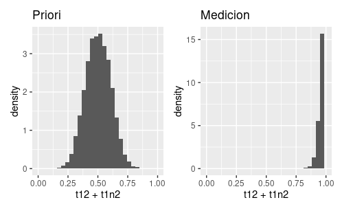

```r
print(g0L$F)
```

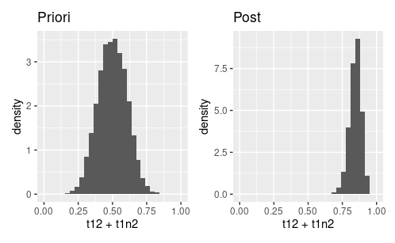

```r
print(g0P$F)
```

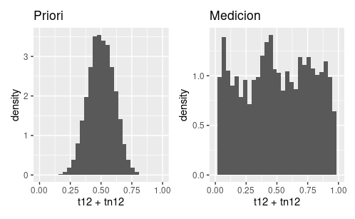

```r
print(g0L$G)
```

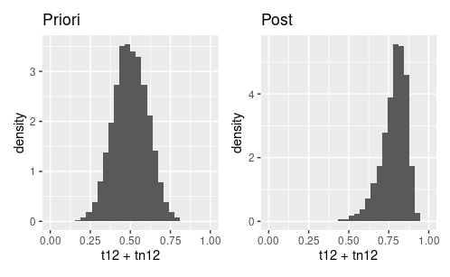

```r
print(g0P$G)
```

#### Ejemplo con dos links

##### En el centro del vértice

Repetimos el mismo modelo que presentamos antes y le agregamos la misma medición. Es decir, medimos que va a estar la persona 1. Esta persona está en el centro del vértice, con lo cual afecta directamente a las personas 2 y 3.

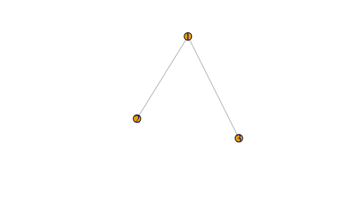

```r
require(igraph)
g = make_empty_graph(n=3,directed=FALSE)
g = add_edges(g,c(1,2,1,3))
plot(g)
```

```r
X = as_adjacency_matrix(g,sparse = FALSE)

Z = generate_state_vector(X)
A = generate_constraint_matrix(X)
P = generate_proyector(A)
gamma = 10
K = 22
kappas = generate_kappas(Z,gamma = gamma,K=K)
H = c(1,1,0,0,0,0)
alfas = c(49,1)
params = list('H'=H,'alfas'=alfas,'kappas'=kappas,'K'=P)


z0 = kappas[c(1:3,5:7)]/K
initial = t(P)%*%z0
density = density_eta
samples0 = sampling(density = density,initial=initial,params=params,full.result = FALSE,scale=6e-2)

initial = colMeans(samples0)
density = density_posteriori_eta
samplesP = sampling(density = density,initial=initial,params=params,full.result = FALSE,scale=6e-2)

initial = colMeans(samples0)
density = density_measure_eta
samplesL = sampling(density = density,initial=initial,params=params,full.result = FALSE,scale=6e-2)

df0 = as.data.frame(t(P%*%t(samples0)))
dfL = as.data.frame(t(P%*%t(samplesL)))
dfP = as.data.frame(t(P%*%t(samplesP)))

colnames(df0) = paste('t',Z,sep='')
colnames(dfL) = paste('t',Z,sep='')
colnames(dfP) = paste('t',Z,sep='')
```

Antes de ver los gráficos, exploremos qué ocurre a los valores medios y varianzas:

Para $\theta_1$:

```r
mean(df0$t12+df0$t1n2)
```

```
[1] 0.5006891
```

```r
sd(df0$t12+df0$t1n2)
```

```
[1] 0.07592533
```

```r
mean(dfL$t12+dfL$t1n2)
```

```
[1] 0.9420369
```

```r
sd(dfL$t12+dfL$t1n2)
```

```
[1] 0.03090777
```

```r
mean(dfP$t12+dfP$t1n2)
```

```
[1] 0.7689712
```

```r
sd(dfP$t12+dfP$t1n2)
```

```
[1] 0.04421343
```

Lo que observamos comparando al caso anterior es que el aumento de la probabilidad es menor (es decir, aumenta menos $E[\theta_1]$). Esto se debe a que al estar conectado a más personas, la masa de probabilidad que debe mover es mayor. Esto lo podemos notar en la desviación estandar de $\theta_1$ en la priori.

Para $\theta_2$:

```r
mean(df0$t12+df0$tn12)
```

```
[1] 0.5006958
```

```r
sd(df0$t12+df0$tn12)
```

```
[1] 0.08526378
```

```r
mean(dfL$t12+dfL$tn12)
```

```
[1] 0.4732354
```

```r
sd(dfL$t12+dfL$tn12)
```

```
[1] 0.2713236
```

```r
mean(dfP$t12+dfP$tn12)
```

```
[1] 0.7184862
```

```r
sd(dfP$t12+dfP$tn12)
```

```
[1] 0.07856553
```

Nuevamente, observamos un aumento en la probabilidad de $\theta_2$. Si bien es levemente menor que en el caso anterior, la diferencia es menos notable que para $\theta_1$.

Para $\theta_3$:

```r
mean(df0$t13+df0$t1n3)
```

```
[1] 0.5006891
```

```r
sd(df0$t13+df0$t1n3)
```

```
[1] 0.07592533
```

```r
mean(dfL$t13+dfL$t1n3)
```

```
[1] 0.9420369
```

```r
sd(dfL$t13+dfL$t1n3)
```

```
[1] 0.03090777
```

```r
mean(dfP$t13+dfP$t1n3)
```

```
[1] 0.7689712
```

```r
sd(dfP$t13+dfP$t1n3)
```

```
[1] 0.04421343
```

Armamos los gráficos

```r
ggL0 = make_ggmagic(df0)
ggLL = make_ggmagic(dfL,gtitle = 'Medición')
ggLP = make_ggmagic(dfP,gtitle = 'Post')
ggL0L = make_ggmagic2(df0, dfL,gtitle2 = 'Medicion')
ggL0P = make_ggmagic2(df0, dfP)
```

Primer set de gráficos

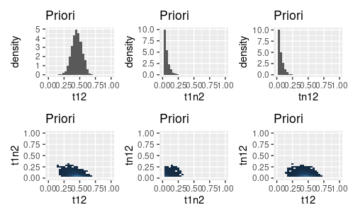

```r
ggL0$gL1
```

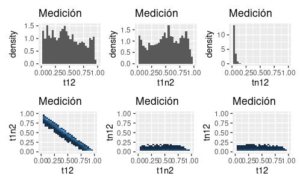

```r
ggLL$gL1
```

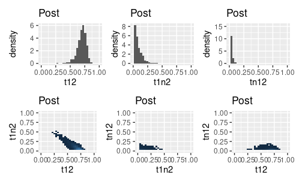

```r
ggLP$gL1
```

Segundo set de gráficos

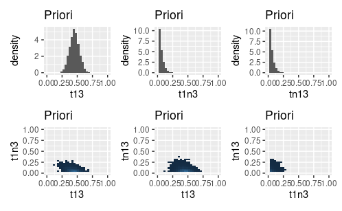

```r
ggL0$gL2
```

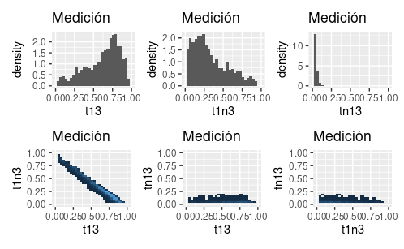

```r
ggLL$gL2
```

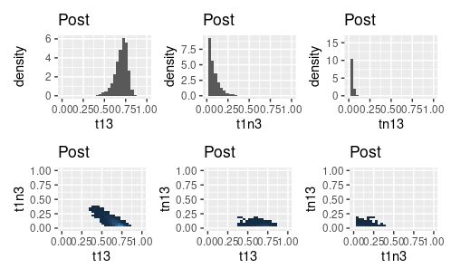

```r
ggLP$gL2
```

Tercer set de gráficos

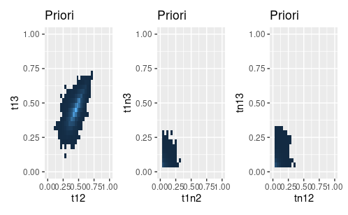

```r
ggL0$gL3
```

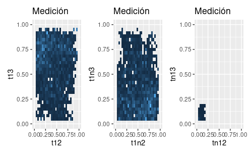

```r
ggLL$gL3
```

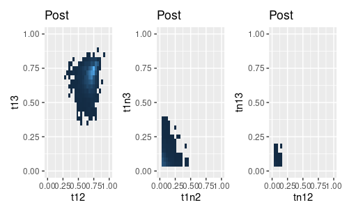

```r
ggLP$gL3
```

Cuarto set de gráficos

```r
print(ggL0P$A)
print(ggL0P$B)
print(ggL0P$C)
print(ggL0P$D)
print(ggL0P$E)
```

[output not shown]

Quinto set de gráficos

```r
print(ggL0P$F)
print(ggL0P$G)
print(ggL0P$H)
```

[output not shown]

##### En el borde del vértice

En este caso vamos a medir sobre la persona 2. Esta persona está en el borde del vértice, con lo cual afecta directamente a la persona 1 e indirectamente a la persona 3.

```r
require(igraph)
g = make_empty_graph(n=3,directed=FALSE)
g = add_edges(g,c(1,2,1,3))
plot(g)
X = as_adjacency_matrix(g,sparse = FALSE)

Z = generate_state_vector(X)
A = generate_constraint_matrix(X)
P = generate_proyector(A)
gamma = 10
K = 22
kappas = generate_kappas(Z,gamma = gamma,K=K)
H = c(1,0,1,0,0,0)
alfas = c(49,1)
params = list('H'=H,'alfas'=alfas,'kappas'=kappas,'K'=P)


z0 = kappas[c(1:3,5:7)]/K
initial = t(P)%*%z0
density = density_eta
samples0 = sampling(density = density,initial=initial,params=params,full.result = FALSE,scale=6e-2)

initial = colMeans(samples0)
density = density_posteriori_eta
samplesP = sampling(density = density,initial=initial,params=params,full.result = FALSE,scale=6e-2)

initial = colMeans(samples0)
density = density_measure_eta
samplesL = sampling(density = density,initial=initial,params=params,full.result = FALSE,scale=6e-2)

df0 = as.data.frame(t(P%*%t(samples0)))
dfL = as.data.frame(t(P%*%t(samplesL)))
dfP = as.data.frame(t(P%*%t(samplesP)))

colnames(df0) = paste('t',Z,sep='')
colnames(dfL) = paste('t',Z,sep='')
colnames(dfP) = paste('t',Z,sep='')
```

Antes de ver los gráficos, exploremos qué ocurre a los valores medios y varianzas:

Para $\theta_2$:

```r
mean(df0$t12+df0$tn12)
```

```
[1] 0.502735
```

```r
sd(df0$t12+df0$tn12)
```

```
[1] 0.08391043
```

```r
mean(dfL$t12+dfL$tn12)
```

```
[1] 0.9608887
```

```r
sd(dfL$t12+dfL$tn12)
```

```
[1] 0.02692678
```

```r
mean(dfP$t12+dfP$tn12)
```

```
[1] 0.8213078
```

```r
sd(dfP$t12+dfP$tn12)
```

```
[1] 0.048267
```

Observamos un aumento en la probabilidad de $\theta_2$, similar al del primer ejemplo con un sólo link.

Para $\theta_1$:

```r
mean(df0$t12+df0$t1n2)
```

```
[1] 0.501781
```

```r
sd(df0$t12+df0$t1n2)
```

```
[1] 0.07469716
```

```r
mean(dfL$t12+dfL$t1n2)
```

```
[1] 0.4543054
```

```r
sd(dfL$t12+dfL$t1n2)
```

```
[1] 0.242113
```

```r
mean(dfP$t12+dfP$t1n2)
```

```
[1] 0.6432009
```

```r
sd(dfP$t12+dfP$t1n2)
```

```
[1] 0.08287157
```

Lo que observamos comparando al caso anterior es que el aumento de la probabilidad es menor (es decir, aumenta menos $E[\theta_1]$). En este caso $\theta_1$ se ve tironeado por dos puntos: la persona 2 aumenta su verosimilitud de estar en el evento, mientras que de la persona 3 no nos llega nueva información por lo que hace de contrapeso.

Para $\theta_3$:

```r
mean(df0$t13+df0$t1n3)
```

```
[1] 0.501781
```

```r
sd(df0$t13+df0$t1n3)
```

```
[1] 0.07469716
```

```r
mean(dfL$t13+dfL$t1n3)
```

```
[1] 0.4543054
```

```r
sd(dfL$t13+dfL$t1n3)
```

```
[1] 0.242113
```

```r
mean(dfP$t13+dfP$t1n3)
```

```
[1] 0.6432009
```

```r
sd(dfP$t13+dfP$t1n3)
```

```
[1] 0.08287157
```

Armamos los gráficos

```r
ggL0 = make_ggmagic(df0)
ggLL = make_ggmagic(dfL,gtitle = 'Medición')
ggLP = make_ggmagic(dfP,gtitle = 'Post')
ggL0L = make_ggmagic2(df0, dfL,gtitle2 = 'Medicion')
ggL0P = make_ggmagic2(df0, dfP)
```

Primer set de gráficos

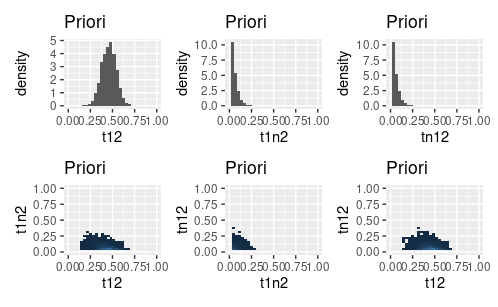

```r
ggL0$gL1
```

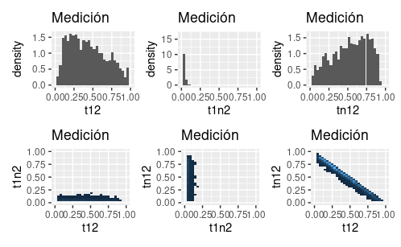

```r
ggLL$gL1
```

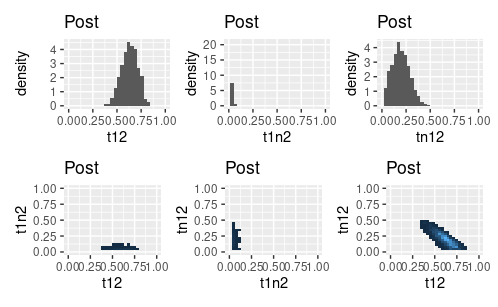

```r
ggLP$gL1
```

Segundo set de gráficos

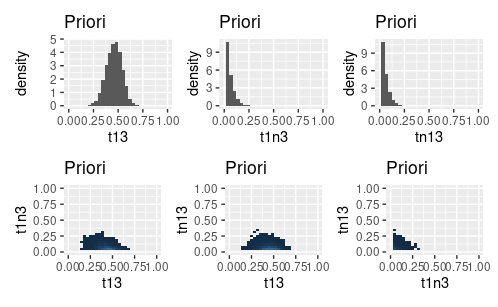

```r
ggL0$gL2
```

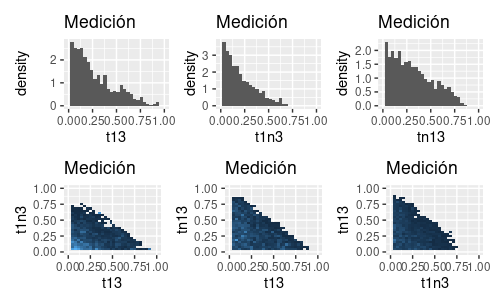

```r
ggLL$gL2
```

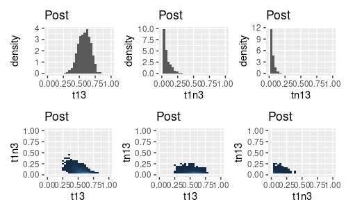

```r
ggLP$gL2
```

Tercer set de gráficos

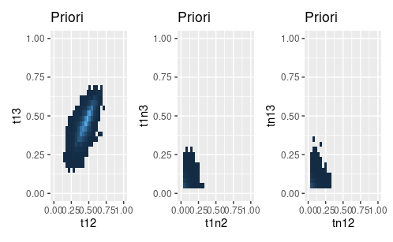

```r
ggL0$gL3
```

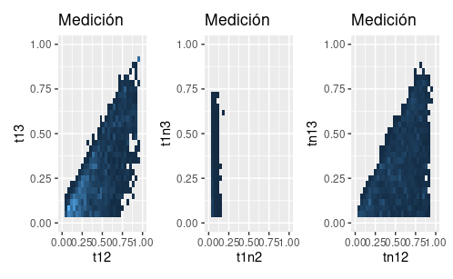

```r
ggLL$gL3
```

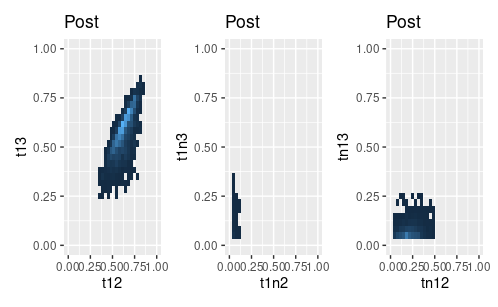

```r
ggLP$gL3
```

Cuarto set de gráficos

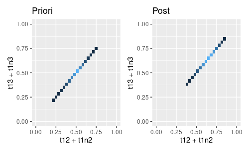

```r
print(ggL0P$A)
```

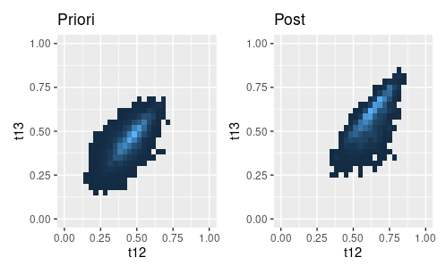

```r
print(ggL0P$B)
```

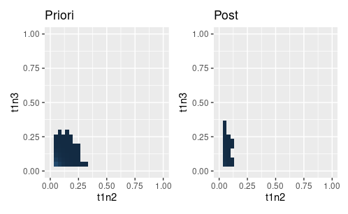

```r
print(ggL0P$C)
```

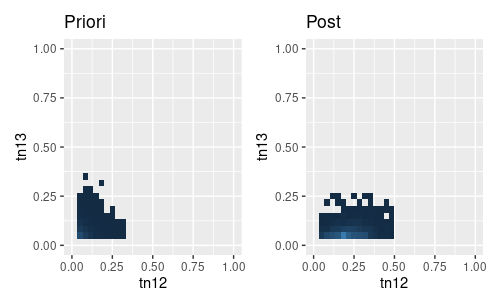

```r
print(ggL0P$D)
```

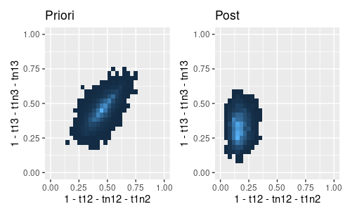

```r
print(ggL0P$E)
```

Quinto set de gráficos

```r
print(ggL0P$F)
print(ggL0P$G)
print(ggL0P$H)
```

[output not shown]

##### Propagación en una cadena

Para explorar como se propaga la información sobre una red sencilla, vamos a considerar una cadena en la cual la información la recibimos de la persona 1, ubicada en un extremo.

```r
require(igraph)
gChains = lapply(3:15,function(len){
  print(len)
  g = make_lattice(dim=1,length=len,directed=FALSE)

  X = as_adjacency_matrix(g,sparse = FALSE)

  Z = generate_state_vector(X)
  A = generate_constraint_matrix(X)
  P = generate_proyector(A)
  gamma = 10
  K = 22
  kappas = generate_kappas(Z,gamma = gamma,K=K)

  z0 = generate_z0(kappas,K)
  H = 0*z0
  H[1:2] = 1
  alfas = c(49,1)
  params = list('H'=H,'alfas'=alfas,'kappas'=kappas,'K'=P)

  initial = t(P)%*%z0
  density = density_posteriori_eta
  samplesP = sampling(density = density,initial=initial,params=params,full.result = FALSE,scale=6e-2,nbatch = 1e6)

  medias = colMeans(samplesP)
  medias = as.numeric(P%*%medias)
  names(medias) = Z
  tSingles = sapply(1:vcount(g),function(i){
    ts = medias[grepl(i,Z) & !grepl(paste('n',i,sep=''),Z)]
    sum(ts)/(length(ts)/2)
  })

  V(g)$theta = tSingles
  return(g)
})
```

[output not shown]

Antes de ver los gráficos, exploremos qué ocurre a los valores medios y varianzas:

Para $\theta_2$:

```r
mean(df0$t12+df0$tn12)
sd(df0$t12+df0$tn12)

mean(dfL$t12+dfL$tn12)
sd(dfL$t12+dfL$tn12)

mean(dfP$t12+dfP$tn12)
sd(dfP$t12+dfP$tn12)
```

[output not shown]

Para $\theta_1$:

```r
mean(df0$t12+df0$t1n2)
sd(df0$t12+df0$t1n2)

mean(dfL$t12+dfL$t1n2)
sd(dfL$t12+dfL$t1n2)

mean(dfP$t12+dfP$t1n2)
sd(dfP$t12+dfP$t1n2)
```

[output not shown]

Para $\theta_3$:

```r
mean(df0$t13+df0$t1n3)
sd(df0$t13+df0$t1n3)

mean(dfL$t13+dfL$t1n3)
sd(dfL$t13+dfL$t1n3)

mean(dfP$t13+dfP$t1n3)
sd(dfP$t13+dfP$t1n3)
```

[output not shown]

Armamos los gráficos

```r
ggL0 = make_ggmagic(df0)
ggLL = make_ggmagic(dfL,gtitle = 'Medición')
ggLP = make_ggmagic(dfP,gtitle = 'Post')
ggL0L = make_ggmagic2(df0, dfL,gtitle2 = 'Medicion')
ggL0P = make_ggmagic2(df0, dfP)
```

Primer set de gráficos

```r
ggL0$gL1
ggLL$gL1
ggLP$gL1
```

[output not shown]

Segundo set de gráficos

```r
ggL0$gL2
ggLL$gL2
ggLP$gL2
```

[output not shown]

Tercer set de gráficos

```r
ggL0$gL3
ggLL$gL3
ggLP$gL3
```

[output not shown]

Cuarto set de gráficos

```r
print(ggL0P$A)
print(ggL0P$B)
print(ggL0P$C)
print(ggL0P$D)
print(ggL0P$E)
```

[output not shown]

Quinto set de gráficos

```r
print(ggL0P$F)
print(ggL0P$G)
print(ggL0P$H)
```

[output not shown]

### Condicionando sobre una de las personas

En el ejemplo anterior vimos el efecto de incorporar información externa referida directamente a los valores de $\theta_{r}$. Este proceso involucra la imagen mental de que un agente externo nos aporta información nueva sobre los valores de los $\theta$ (por ejemplo, alguien sabe con cierta probabilidad que la persona r está en el evento).

En este apartado la búsqueda será distinta. En vez de preguntarnos por lo $\theta$, y recibir información sobre ellos, exploraremos como condicionar sobre el hecho de que una persona esté presente en el evento.

#### Volviendo sobre dos personas

Consideremos por un momento que sólo hay dos personas (1 y 2), cuya distribución de probabilidad conjunta está dada por $z_{12}=(\theta_{12},\theta_{1 \bar 2},\theta_{\bar 1 2})$. Partimos de que

$$\begin{align}
P(12) = \theta_{12} \\
P(1) = \theta_{12} + \theta_{1 \bar 2}
\end{align}$$

Entonces, para calcular $P(2|1)$ hacemos

$$\begin{align}
P(2|1) = \frac{P(12)}{P(1)} = \frac{\theta_{12}}{\theta_{12} + \theta_{1 \bar 2}} = \theta_{2|1} \\
P(\bar 2 | 1) = \frac{P(1 \bar 2)}{P(1)} = \frac{\theta_{1 \bar 2}}{\theta_{12} + \theta_{1 \bar 2}} = \theta_{\bar 2|1} \\
\end{align}$$

Es decir que la distribución condicional la obtenemos a partir de la distribución original. Lo que tenemos que hacer es realizar operaciones sobre los $\theta_{rs}$.

Formalmente, si quisieramos obtener la distribución exacta para $\theta_{2|1}$, tendríamos que usar que

$$\begin{align}
f_{12}(z_{12}) &= \frac{\Gamma(\kappa)}{\Gamma(\kappa_{12}) \Gamma(\kappa_{1 \bar 2}) \Gamma(\kappa_{\bar 1 2}) \Gamma(\kappa_{\bar 1 \bar 2})} \theta_{12}^{\kappa_{12}-1} \theta_{1 \bar 2}^{\kappa_{1\bar 2}-1} \theta_{\bar 1 2}^{\kappa_{\bar 1 2}-1} (1-\theta_{12}-\theta_{1 \bar 2}-\theta_{\bar 1 2})^{\kappa_{\bar 1 \bar 2}-1} \\
f_{2|1}(\theta_{2|1}) &= \int dz_{12} \ \delta(\theta_{2|1} - \frac{\theta_{12}}{\theta_{12}+\theta_{1\bar2}}) f_{12}(z_{12})
\end{align}$$

En este caso, en vez de realizar este cálculo, lo que haremos será computar muestras de $f_{12}$ y usarlas para calcular $\theta_{2|1}$.

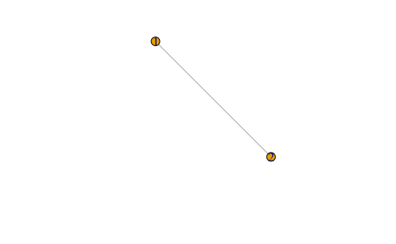

```r
require(igraph)
g = make_empty_graph(n=2,directed=FALSE)
g = add_edges(g,c(1,2))
plot(g)
```

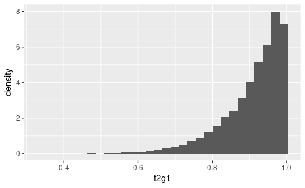

```r
X = as_adjacency_matrix(g,sparse = FALSE)

Z = generate_state_vector(X)
gamma = 10
K = 22
kappas = generate_kappas(Z,gamma = gamma,K=K)
params = list('kappas'=kappas)


z0 = generate_z0(kappas,K)
initial = z0
density = density_comb
samples0 = sampling(density = density,initial=initial,params=params,full.result = FALSE,scale=6e-2)



df0 = as.data.frame(samples0)
colnames(df0) = paste('t',Z,sep='')

df0$t2g1 = df0$t12/(df0$t12+df0$t1n2)
ggplot(data=df0,mapping=aes(x=t2g1,y=..density..)) + geom_histogram()
```

Lo que vemos acá es que al condicionar sobre la persona 1, la persona 2 tiene una densidad concentrada cerca de uno. Esto ocurre porque la operación de marginalizar recorta todo lo asociado a $\bar 1$. Al quedarnos sólo con los $\theta$ asociados a $1$, y siendo que $\theta_{12}\gg \theta_{1\bar2}$ (dado que nuestra priori es que estarán juntos), el resultado es una distribución para $\theta_{2|1}$ (`t2g1`) concentrada en 1. Si la pensaramos como una distribución beta, tendría los parámetros:

```r
esp = mean(df0$t2g1)
vari = var(df0$t2g1)
alfa = esp*(1-esp)/vari-1
alfa1 = esp*alfa
alfa2 = (1-esp)*alfa
print(c(alfa1,alfa2))
```

```
[1] 10.307235  1.024043
```

```r
print(kappas)
```

```
[1] 10  1  1 10
```

Numéricamente, este resultado nos sugiere que la distribución que obtenemos es equivalente a fijar $\kappa_{\bar 1 2} = \kappa_{\bar 1 \bar 2} = 0$. Esta hipótesis necesitaría ser explorada más detalladamente.

#### Considerando tres personas, en una linea recta

Ahora que ya sabemos qué hacer para condicionar cuando dos personas está vinculadas directamente, veamos qué ocurre cuando condicionamos sobre la presencia de la persona 1, sobre las personas 2 y 3.

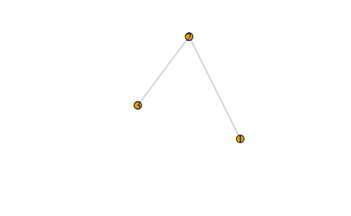

```r
require(igraph)
make_empty_graph(n=3,directed=FALSE) %>% add_edges(edges=c(1,2,2,3)) %>% plot()
```

Recordemos que en este caso tenemos como vector de probabilidades a $z=(z_{12},z_{23}) = (\theta_{12},\theta_{1 \bar 2}, \theta_{\bar 1 2},\theta_{23},\theta_{2 \bar 3}, \theta_{\bar 2 3})$. Al considerar esta red, estamos suponiendo que $P(3|21) = P(3|2)$ y que $P(1|23)=P(1|2)$. Esto significa que condicionando en la presencia de la persona 2, la presencia de la persona 1 es irrelevante para la 3 y viceversa. A partir del ejemplo anterior ya sabemos que

$$P(2|1) = \frac{P(12)}{P(1)} = \frac{\theta_{12}}{\theta_{12} + \theta_{1 \bar 2}}$$

En este caso, al condicionar sobre la presencia de la persona 1, lo que nos queda es un link, que va a estar descripto por $z_{23|1}=(\theta_{23|1},\theta_{2 \bar 3|1},\theta_{\bar 2 3|1})$. Nuestro objetivo entonces es construir a $z_{23|1}$ a partir de $z_{12}$ y $z_{23}$. Bajo la suposición de la independencia condicional tenemos que

$$\begin{align}
P(23|1) &= P(3|21)P(2|1) = P(3|2)P(2|1) = P(3|2)\frac{P(2)}{P(2)}P(2|1) = P(23) \frac{P(2|1)}{P(2)} \\
&= \theta_{23} \frac{\theta_{2|1}}{\theta_2} = \frac{\theta_{23}\theta_{12}}{(\theta_{12}+\theta_{1 \bar 2})(\theta_{12}+\theta_{\bar 1 2})}
\end{align}$$

De forma similar, podemos escribir las ecuaciones para los tres elementos de $z_{23|1}$:

$$\begin{align}
\theta_{23|1} = \frac{\theta_{23}\theta_{12}}{(\theta_{12}+\theta_{1 \bar 2})(\theta_{12}+\theta_{\bar 1 2})} = \theta_{23} \frac{\theta_{12}}{\theta_1 \theta_2} \\
\theta_{2 \bar 3|1} = \frac{\theta_{2 \bar 3}\theta_{12}}{(\theta_{12}+\theta_{1 \bar 2})(\theta_{12}+\theta_{\bar 1 2})} = \theta_{2 \bar 3} \frac{\theta_{12}}{\theta_1 \theta_2} \\
\theta_{\bar 2 3|1} = \frac{\theta_{\bar 2 3}\theta_{1 \bar2}}{(\theta_{12}+\theta_{1 \bar 2})(\theta_{1 \bar 2}+\theta_{\bar 1 \bar 2})} = \theta_{\bar 2 3} \frac{\theta_{1 \bar 2}}{\theta_1 (1- \theta_2)} \\
\end{align}$$

Nuevamente, para construir nuestra función de probabilidad $f_{23|1}(z_{23|1})$ tendríamos que integrar una delta de Dirac sobre estos valores. En vez de eso, calculemos la distribución de estos parámetros numéricamente.

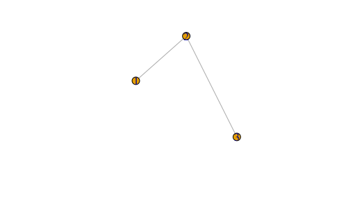

```r
require(igraph)
g = make_empty_graph(n=3,directed=FALSE)
g = add_edges(g,c(1,2,2,3))
plot(g)
```

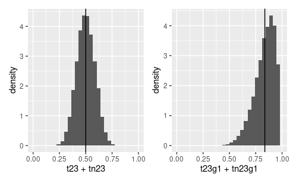

```r
X = as_adjacency_matrix(g,sparse = FALSE)
A = generate_constraint_matrix(X)
P = generate_proyector(A)

Z = generate_state_vector(X)
gamma = 10
K = 22
kappas = generate_kappas(Z,gamma = gamma,K=K)

params = list('kappas'=kappas,'K'=P)

z0 = generate_z0(kappas,K)
initial = t(P)%*%z0
density = density_eta
samples0 = sampling(density = density,initial=initial,params=params,full.result = FALSE,scale=6e-2,nbatch = 1e6)

df0 = as.data.frame(t(P%*%t(samples0)))
colnames(df0) = paste('t',Z,sep='')

df0$t1 = df0$t12+df0$t1n2
df0$t2 = df0$t12+df0$tn12
df0$t23g1 = df0$t23*df0$t12/(df0$t1*df0$t2)
df0$t2n3g1 = df0$t2n3*df0$t12/(df0$t1*df0$t2)
df0$tn23g1 = df0$tn23*df0$t1n2/(df0$t1*(1-df0$t2))

ggplot(data=df0,mapping=aes(x=t23+tn23,y=..density..)) + geom_histogram() + geom_vline(xintercept = mean(df0$t23+df0$tn23)) + xlim(c(0,1)) + ggplot(data=df0,mapping=aes(x=t23g1+tn23g1,y=..density..)) + geom_histogram() + geom_vline(xintercept = mean(df0$t23g1+df0$tn23g1)) + xlim(c(0,1))
```

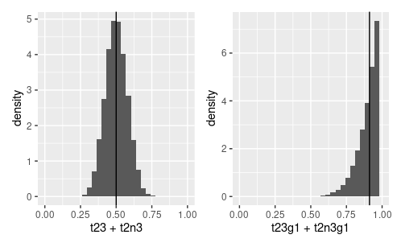

```r
ggplot(data=df0,mapping=aes(x=t23+t2n3,y=..density..)) + geom_histogram() + geom_vline(xintercept = mean(df0$t23+df0$t2n3)) + xlim(c(0,1)) + ggplot(data=df0,mapping=aes(x=t23g1+t2n3g1,y=..density..)) + geom_histogram() + geom_vline(xintercept = mean(df0$t23g1+df0$t2n3g1)) + xlim(c(0,1))
```

```r
paste('t2->t2g1:',paste(round(mean(df0$t23+df0$t2n3),2),round(mean(df0$t23g1+df0$t2n3g1),2),sep='->'))
```

```
[1] "t2->t2g1: 0.5->0.91"
```

```r
paste('t3->t3g1:',paste(round(mean(df0$t23+df0$tn23),2),round(mean(df0$t23g1+df0$tn23g1),2),sep='->'))
```

```
[1] "t3->t3g1: 0.5->0.84"
```

De estas distribuciones vemos que el efecto de la presencia de la persona 1 se atenua a medida que nos alejamos de ella en la red. Mientras que $\theta_2=0.5$ pasa a $\theta_{2|1}=0.91$, $\theta_3 = 0.5$ pasa a $\theta_{3|1}=0.84$.

#### Considerando cuatro personas en una cadena

Para identificar como se propaga el condicionamiento en una cadena más larga, estudiemos una cadena formada por cuatro personas.

En este caso, nuestro vector de probabilidades está dado por $z=(z_{12},z_{23},z_{34})$. Luego de condicionar, nuestro nuevo vector estará dado por $z_{|1} =(z_{23|1},z_{34|1})$. El vector $z_{23|1}$ ya aprendimos como construirlo. Veamos como construimos el vector $z_{34|1}$ en función el vector $z_{23|1}$. Para eso necesitamos construir $P(34|1)$. Veamos:

$$P(34|1) = P(4|31)P(3|1) = P(4|3)P(3|1) = P(34) \frac{P(3|1)}{P(3)} = \theta_{34} \frac{\theta_{3|1}}{\theta_3} = \theta_{34|1}$$

De forma similar, tenemos que

$$\begin{align}
\theta_{34|1} = \theta_{34} \frac{\theta_{3|1}}{\theta_3} \\
\theta_{3 \bar 4|1} = \theta_{3 \bar 4} \frac{\theta_{3|1}}{\theta_3} \\
\theta_{\bar 3 4|1} = \theta_{\bar 3 4} \frac{\theta_{\bar 3|1}}{\theta_{\bar 3}} \\
\end{align}$$
En general, vemos que si lo que estamos siguiendo es una cadena lineal desde el par rs hasta la persona 1, tendremos que actualizar haciendo

$$\theta_{rs|1} = \theta_{rs} \frac{\theta_{r|1}}{\theta_r}$$
donde la persona r es la que está más cerca de la persona 1.

Veamos como resulta en este ejemplo la difuminación a lo largo de la cadena.

```r
require(igraph)
g = make_empty_graph(n=4,directed=FALSE)
g = add_edges(g,c(1,2,2,3,3,4))
plot(g)
X = as_adjacency_matrix(g,sparse = FALSE)
A = generate_constraint_matrix(X)
P = generate_proyector(A)

Z = generate_state_vector(X)
gamma = 10
K = 22
kappas = generate_kappas(Z,gamma = gamma,K=K)

params = list('kappas'=kappas,'K'=P)

z0 = generate_z0(kappas,K)
initial = t(P)%*%z0
density = density_eta
samples0 = sampling(density = density,initial=initial,params=params,full.result = FALSE,scale=6e-2,nbatch = 1e6)

df0 = as.data.frame(t(P%*%t(samples0)))
colnames(df0) = paste('t',Z,sep='')

df0$t1 = df0$t12+df0$t1n2
df0$t2 = df0$t12+df0$tn12
df0$t3 = df0$t34+df0$t3n4
df0$t4 = df0$t34+df0$tn34

df0$t2g1 = df0$t12/df0$t1

df0$t23g1 = df0$t23*df0$t2g1/df0$t2
df0$t2n3g1 = df0$t2n3*df0$t2g1/df0$t2
df0$tn23g1 = df0$tn23*(1-df0$t2g1)/(1-df0$t2)

df0$t3g1 = df0$t23g1+df0$tn23g1

df0$t34g1 = df0$t34*df0$t3g1/df0$t3
df0$t3n4g1 = df0$t2n3*df0$t3g1/df0$t3
df0$tn34g1 = df0$tn23*(1-df0$t3g1)/(1-df0$t3)

df0$t4g1 = df0$t34g1+df0$tn34g1


ggplot(data=df0,mapping=aes(x=t2,y=..density..)) + geom_histogram() + geom_vline(xintercept = mean(df0$t2)) + xlim(c(0,1)) + ggplot(data=df0,mapping=aes(x=t2g1,y=..density..)) + geom_histogram() + geom_vline(xintercept = mean(df0$t2g1)) + xlim(c(0,1))
```

[output not shown]

Veamos un ejemplo idéntico más, pero con más personas:

```r
require(igraph)
require(ggplot2)
require(patchwork)
source('repo.R')
g = make_empty_graph(n=10,directed=FALSE)
g = add_edges(g,c(1,2,2,3,3,4,4,5,5,6,6,7,7,8,8,9,9,10))
plot(g)
X = as_adjacency_matrix(g,sparse = FALSE)
A = generate_constraint_matrix(X)
P = generate_proyector(A)

Z = generate_state_vector(X)
gamma = 10
K = 22
kappas = generate_kappas(Z,gamma = gamma,K=K)

params = list('kappas'=kappas,'K'=P)

z0 = generate_z0(kappas,K)
initial = t(P)%*%z0
density = density_eta
samples0 = sampling(density = density,initial=initial,params=params,full.result = FALSE,scale=6e-2,nbatch = 1e6)

df0 = as.data.frame(t(P%*%t(samples0)))
colnames(df0) = paste('t',Z,sep='')

df0$t1 = df0$t12+df0$t1n2
df0$t2 = df0$t12+df0$tn12
df0$t3 = df0$t34+df0$t3n4
df0$t4 = df0$t34+df0$tn34
df0$t5 = df0$t45+df0$tn45
df0$t6 = df0$t56+df0$tn56
df0$t7 = df0$t67+df0$tn67
df0$t8 = df0$t78+df0$tn78
df0$t9 = df0$t89+df0$tn89
df0$t10 = df0$t910+df0$tn910

df0$t2g1 = df0$t12/df0$t1

df0$t23g1 = df0$t23*df0$t2g1/df0$t2
df0$t2n3g1 = df0$t2n3*df0$t2g1/df0$t2
df0$tn23g1 = df0$tn23*(1-df0$t2g1)/(1-df0$t2)

df0$t3g1 = df0$t23g1+df0$tn23g1

df0$t34g1 = df0$t34*df0$t3g1/df0$t3
df0$t3n4g1 = df0$t2n3*df0$t3g1/df0$t3
df0$tn34g1 = df0$tn23*(1-df0$t3g1)/(1-df0$t3)

df0$t4g1 = df0$t34g1+df0$tn34g1

df0$t45g1 = df0$t45*df0$t4g1/df0$t4
df0$t4n5g1 = df0$t4n5*df0$t4g1/df0$t4
df0$tn45g1 = df0$tn45*(1-df0$t4g1)/(1-df0$t4)

df0$t5g1 = df0$t45g1+df0$tn45g1

df0$t56g1 = df0$t56*df0$t5g1/df0$t5
df0$t5n6g1 = df0$t5n6*df0$t5g1/df0$t5
df0$tn56g1 = df0$tn56*(1-df0$t5g1)/(1-df0$t5)

df0$t6g1 = df0$t56g1+df0$tn56g1

df0$t67g1 = df0$t67*df0$t6g1/df0$t6
df0$t6n7g1 = df0$t6n7*df0$t6g1/df0$t6
df0$tn67g1 = df0$tn67*(1-df0$t6g1)/(1-df0$t6)

df0$t7g1 = df0$t67g1+df0$tn67g1

df0$t78g1 = df0$t78*df0$t7g1/df0$t7
df0$t7n8g1 = df0$t7n8*df0$t7g1/df0$t7
df0$tn78g1 = df0$tn78*(1-df0$t7g1)/(1-df0$t7)

df0$t8g1 = df0$t78g1+df0$tn78g1

df0$t89g1 = df0$t89*df0$t8g1/df0$t8
df0$t8n9g1 = df0$t8n9*df0$t8g1/df0$t8
df0$tn89g1 = df0$tn89*(1-df0$t8g1)/(1-df0$t8)

df0$t9g1 = df0$t89g1+df0$tn89g1

df0$t910g1 = df0$t910*df0$t9g1/df0$t9
df0$t9n10g1 = df0$t9n10*df0$t9g1/df0$t9
df0$tn910g1 = df0$tn910*(1-df0$t9g1)/(1-df0$t9)

df0$t10g1 = df0$t910g1+df0$tn910g1




ggplot(data=df0,mapping=aes(x=t2,y=..density..)) + geom_histogram() + geom_vline(xintercept = mean(df0$t2)) + xlim(c(0,1)) + ggplot(data=df0,mapping=aes(x=t2g1,y=..density..)) + geom_histogram() + geom_vline(xintercept = mean(df0$t2g1)) + xlim(c(0,1))

ggplot(data=df0,mapping=aes(x=t3,y=..density..)) + geom_histogram() + geom_vline(xintercept = mean(df0$t3)) + xlim(c(0,1)) + ggplot(data=df0,mapping=aes(x=t3g1,y=..density..)) + geom_histogram() + geom_vline(xintercept = mean(df0$t3g1)) + xlim(c(0,1))

ggplot(data=df0,mapping=aes(x=t4,y=..density..)) + geom_histogram() + geom_vline(xintercept = mean(df0$t4)) + xlim(c(0,1)) + ggplot(data=df0,mapping=aes(x=t4g1,y=..density..)) + geom_histogram() + geom_vline(xintercept = mean(df0$t4g1)) + xlim(c(0,1))

ggplot(data=df0,mapping=aes(x=t5,y=..density..)) + geom_histogram() + geom_vline(xintercept = mean(df0$t5)) + xlim(c(0,1)) + ggplot(data=df0,mapping=aes(x=t5g1,y=..density..)) + geom_histogram() + geom_vline(xintercept = mean(df0$t5g1)) + xlim(c(0,1))

ggplot(data=df0,mapping=aes(x=t6,y=..density..)) + geom_histogram() + geom_vline(xintercept = mean(df0$t6)) + xlim(c(0,1)) + ggplot(data=df0,mapping=aes(x=t6g1,y=..density..)) + geom_histogram() + geom_vline(xintercept = mean(df0$t6g1)) + xlim(c(0,1))

ggplot(data=df0,mapping=aes(x=t4,y=..density..)) + geom_histogram() + geom_vline(xintercept = mean(df0$t7)) + xlim(c(0,1)) + ggplot(data=df0,mapping=aes(x=t7g1,y=..density..)) + geom_histogram() + geom_vline(xintercept = mean(df0$t7g1)) + xlim(c(0,1))

ggplot(data=df0,mapping=aes(x=t8,y=..density..)) + geom_histogram() + geom_vline(xintercept = mean(df0$t8)) + xlim(c(0,1)) + ggplot(data=df0,mapping=aes(x=t8g1,y=..density..)) + geom_histogram() + geom_vline(xintercept = mean(df0$t8g1)) + xlim(c(0,1))

ggplot(data=df0,mapping=aes(x=t9,y=..density..)) + geom_histogram() + geom_vline(xintercept = mean(df0$t9)) + xlim(c(0,1)) + ggplot(data=df0,mapping=aes(x=t9g1,y=..density..)) + geom_histogram() + geom_vline(xintercept = mean(df0$t9g1)) + xlim(c(0,1))

ggplot(data=df0,mapping=aes(x=t10,y=..density..)) + geom_histogram() + geom_vline(xintercept = mean(df0$t10)) + xlim(c(0,1)) + ggplot(data=df0,mapping=aes(x=t10g1,y=..density..)) + geom_histogram() + geom_vline(xintercept = mean(df0$t10g1)) + xlim(c(0,1))


paste('t2->t2g1:',paste(round(mean(df0$t2),2),round(mean(df0$t2g1),2),sep='->'))
paste('t3->t3g1:',paste(round(mean(df0$t3),2),round(mean(df0$t3g1),2),sep='->'))
paste('t4->t4g1:',paste(round(mean(df0$t4),2),round(mean(df0$t4g1),2),sep='->'))
paste('t5->t5g1:',paste(round(mean(df0$t5),2),round(mean(df0$t5g1),2),sep='->'))
paste('t6->t6g1:',paste(round(mean(df0$t6),2),round(mean(df0$t6g1),2),sep='->'))
paste('t7->t7g1:',paste(round(mean(df0$t7),2),round(mean(df0$t7g1),2),sep='->'))
paste('t8->t8g1:',paste(round(mean(df0$t8),2),round(mean(df0$t8g1),2),sep='->'))
paste('t9->t9g1:',paste(round(mean(df0$t9),2),round(mean(df0$t9g1),2),sep='->'))
paste('t10->t10g1:',paste(round(mean(df0$t10),2),round(mean(df0$t10g1),2),sep='->'))
```

[output not shown]

¿Cómo cambia el efecto conforme nos alejamos? Una forma de visualizarlo (más allá de observar directamente las distribuciones) es graficar la el cociente de probabilidades en función de la distancia.

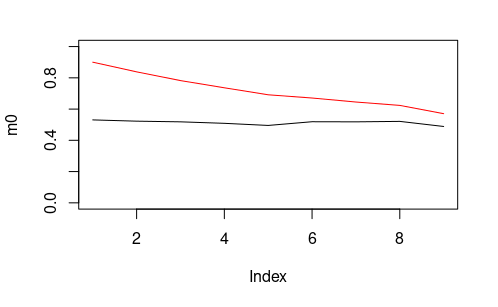

```r
m0 = sapply(2:10,function(i) mean(df0[,paste('t',i,sep='')]))
m1 = sapply(2:10,function(i) mean(df0[,paste('t',i,'g1',sep='')]))
plot(m0,ylim=c(0,1),type='l')
lines(m1,ylim=c(0,1),col='red')
```

```r
plot(m0/(1-m0),ylim=c(10^-1,10),log='yx')
points(m1/(1-m1),ylim=c(0,1),col='red')
```

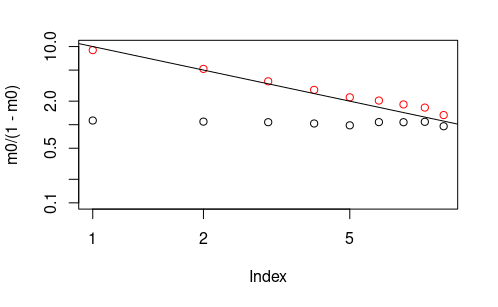

```r
abline(a=1,b=-1)
```

```r
NA
NA
```

#### El tríangulo, una vez más

A diferencia de los ejemplos estilo *cadena* que vimos recién, donde teníamos una relación de independencia condicional ($P(123) = P(3|2)P(2|1) P(1)$), en el tríangulo esta relación no se sostiene.

Esto es debido a qué en el triángulo tenemos relaciones entre todos los elementos. Si intentaramos resolverlo a igual que antes, encontraríamos:

$$\begin{align}
P(2|1) = \frac{\theta_{12}}{\theta_1} \\
P(3|1) = \frac{\theta_{13}}{\theta_1} \\
P(23|1) = P(2|31) P(3|1) \neq P(2|3) P(3|1) \\
P(23|1) = P(3|21) P(2|1) \neq P(3|2) P(2|1) \\
\end{align}$$

El problema aparece porque no podemos aproximar $P(3|21) \approx P(3|2$. Veo dos posibles soluciones a esto:

- Calcular de alguna forma $P(r|sq)$.
- Calcular directamente $P(rs|q)$.

Si tuvieramos una herramienta para condicionar dos veces, podríamos usar la primer opción. La segunda no es claro como la implementaríamos.

Pensando en la primer opción, tenemos que $P(3|21) = P(23|1)/P(2|1)$, con lo cual para poder condicionar sobre ambos necesitamos esa piecita extra de información.

Pensando en la segunda opción, podemos imaginar por un momento que conocemos la distribución de a tres personas $P(123),P(12\bar3),\dots$. Si conocieramos esta distribución, podríamos marginalizar simplemente haciendo

$$P(23|1) = \frac{P(123)}{P(1)} = \frac{\theta_{123}}{\theta_1}$$

El problema es que con la información que estamos trabajando, no tenemos conocimiento de cuál es el valor de $\theta_{123}$. Lo único que conocemos son sus marginales. Recordemos que tenemos la relación

$$\left[ \begin{array}{c} \theta_{12} \\ \theta_{1 \bar 2} \\ \theta_{\bar 1 2} \\ \theta_{13} \\ \theta_{1 \bar 3} \\ \theta_{\bar 1 3} \\ \theta_{23} \\ \theta_{2 \bar 3} \\ \theta_{\bar 2 3} \end{array} \right]
=
\left[ \begin{array}{ccccccc}
1 & 1 & 0 & 0 & 0 & 0 & 0 \\
0 & 0 & 1 & 1 & 0 & 0 & 0\\
0 & 0 & 0 & 0 & 1 & 1 & 0\\
1 & 0 & 1 & 0 & 0 & 0 & 0 \\
0 & 1 & 0 & 1 & 0 & 0 & 0 \\
0 & 0 & 0 & 0 & 1 & 0 & 1 \\
1 & 0 & 0 & 0 & 1 & 0 & 0 \\
0 & 1 & 0 & 0 & 0 & 1 & 0 \\
0 & 0 & 1 & 0 & 0 & 0 & 1 \\
\end{array} \right]
\left[ \begin{array}{c} \theta_{123} \\ \theta_{1 2 \bar 3} \\ \theta_{1 \bar 2 3} \\ \theta_{1\bar 2 \bar 3} \\ \theta_{\bar123} \\ \theta_{\bar 1 2 \bar 3} \\ \theta_{\bar 1 \bar 2 3} \\ \end{array} \right]$$

```r
source('repo.R')
```